[figure not shown]

[figure not shown]

# О продукте.

Amazone Alexa - виртуальный ассистент, разработанный компанией Amazon и впервые появившийся в умных колонках Amazon Echo и Amazon Echo Dot.

Ассистент поддерживает голосовое общение, воспроизведение музыки, подкастов и аудиокниг, составление списков дел, настройку будильников, предоставление актуальной информации о погоде, трафике, спорте, новостях и т. п., управление устройствами в умном доме.

В значительной степени разработана на основе польского синтезатора речи Ivona, приобретенного Amazon в январе 24, 2013.

Название Alexa было выбрано не случайно, так как по словам разработчиков тредое "X" помогает распознавать его с большей точностью.

Официальный запуск — 6 ноября 2014 года вместе с первым устройством Echo.

# Датасет.

В данном датасете представлено более 3000 отзывов покупателей о приобретённых продуктах Amazon Alexa в 2018 году, за период с 16 мая по 31 июля. Содержит 5 переменных: rating, date, variation, verified_reviews, feedback.

## Переменные.

### `feedback`

Зависимая бинарная переменная отражающая характер отзыва.

- 1 - отзыв положительный. (positive)
- 0 - отзыв отрицательный. (negative)

### rating

Признак звездного рейтинга - оценка, которая выдается покупателем после покупки и тестирования приобретенного продукта. Вариируется в диапозоне от 1 до 5.

### date

Переменная даты отзыва. С большой вероятностью отражает дату покупки.

### verified_reviews

Отзывы которые оставлены клиентами или официальными сотрудниками, которые действительно тестировали различные продукты и отмечены как проверенные Amazon.

# Гипотезы:

1. Характер отзыва зависит от отзыва покупателя. (verified_reviews)
2. Характер отзыва зависит от оценки выставленной покупателем. (rating)
3. Характер отзыва зависит от версии продукта. (variation)
4. Характер отзыва в меньшей степени зависит от даты отзыва. (date)

# Цели

1. Выявление и определение проблемы.
2. Определите требования к решению проблемы.
3. Сбор и подготовка данных.
4. Первичный анализ.
5. Предварительный анализ переменных данных (EDA)
6. Подготовка и обработка данных.
7. Разработка функциональных возможностей.
8. Разработка базовой модели и тестирование различных алгоритмов.
9. Построение нескольких моделей.
10. Оценка моделей и выбор наилучшей из них.
11. Итоговое заключение по решению.

# 1. import Library.

```python
import pandas as pd
import numpy as np
import matplotlib.pyplot as plt
import seaborn as sns
from sklearn.feature_extraction.text import CountVectorizer
```

# 2. import Dataset.

```python
data = pd.read_csv('../dataset/amazon_alexa.tsv', sep='\t')
data
```

|  | rating | date | variation | verified_reviews | feedback |
| --- | --- | --- | --- | --- | --- |
| 0 | 5 | 31-Jul-18 | Charcoal Fabric | Love my Echo! | 1 |
| 1 | 5 | 31-Jul-18 | Charcoal Fabric | Loved it! | 1 |
| 2 | 4 | 31-Jul-18 | Walnut Finish | Sometimes while playing a game, you can answer... | 1 |
| 3 | 5 | 31-Jul-18 | Charcoal Fabric | I have had a lot of fun with this thing. My 4 ... | 1 |
| 4 | 5 | 31-Jul-18 | Charcoal Fabric | Music | 1 |
| ... | ... | ... | ... | ... | ... |
| 3145 | 5 | 30-Jul-18 | Black Dot | Perfect for kids, adults and everyone in betwe... | 1 |
| 3146 | 5 | 30-Jul-18 | Black Dot | Listening to music, searching locations, check... | 1 |
| 3147 | 5 | 30-Jul-18 | Black Dot | I do love these things, i have them running my... | 1 |
| 3148 | 5 | 30-Jul-18 | White Dot | Only complaint I have is that the sound qualit... | 1 |
| 3149 | 4 | 29-Jul-18 | Black Dot | Good | 1 |

3150 rows × 5 columns

```python
# переводим переменную date к типу datetime
data.date = pd.to_datetime(data.date, format='mixed')
data.head(10)
```

|  | rating | date | variation | verified_reviews | feedback |
| --- | --- | --- | --- | --- | --- |
| 0 | 5 | 2018-07-31 | Charcoal Fabric | Love my Echo! | 1 |
| 1 | 5 | 2018-07-31 | Charcoal Fabric | Loved it! | 1 |
| 2 | 4 | 2018-07-31 | Walnut Finish | Sometimes while playing a game, you can answer... | 1 |
| 3 | 5 | 2018-07-31 | Charcoal Fabric | I have had a lot of fun with this thing. My 4 ... | 1 |
| 4 | 5 | 2018-07-31 | Charcoal Fabric | Music | 1 |
| 5 | 5 | 2018-07-31 | Heather Gray Fabric | I received the echo as a gift. I needed anothe... | 1 |
| 6 | 3 | 2018-07-31 | Sandstone Fabric | Without having a cellphone, I cannot use many ... | 1 |
| 7 | 5 | 2018-07-31 | Charcoal Fabric | I think this is the 5th one I've purchased. I'... | 1 |
| 8 | 5 | 2018-07-30 | Heather Gray Fabric | looks great | 1 |
| 9 | 5 | 2018-07-30 | Heather Gray Fabric | Love it! I’ve listened to songs I haven’t hear... | 1 |

# 3. Data Analysis

```python
data.info()
```

```
<class 'pandas.core.frame.DataFrame'>
RangeIndex: 3150 entries, 0 to 3149
Data columns (total 5 columns):
 #   Column            Non-Null Count  Dtype
---  ------            --------------  -----
 0   rating            3150 non-null   int64
 1   date              3150 non-null   datetime64[ns]
 2   variation         3150 non-null   object
 3   verified_reviews  3149 non-null   object
 4   feedback          3150 non-null   int64
dtypes: datetime64[ns](1), int64(2), object(2)
memory usage: 123.2+ KB
```

```python
data.describe(include='all')
```

|  | rating | date | variation | verified_reviews | feedback |
| --- | --- | --- | --- | --- | --- |
| count | 3150.000000 | 3150 | 3150 | 3149 | 3150.000000 |
| unique | NaN | NaN | 16 | 2300 | NaN |
| top | NaN | NaN | Black Dot |  | NaN |
| freq | NaN | NaN | 516 | 79 | NaN |
| mean | 4.463175 | 2018-07-24 02:39:05.142857472 | NaN | NaN | 0.918413 |
| min | 1.000000 | 2018-05-16 00:00:00 | NaN | NaN | 0.000000 |
| 25% | 4.000000 | 2018-07-28 00:00:00 | NaN | NaN | 1.000000 |
| 50% | 5.000000 | 2018-07-30 00:00:00 | NaN | NaN | 1.000000 |
| 75% | 5.000000 | 2018-07-30 00:00:00 | NaN | NaN | 1.000000 |
| max | 5.000000 | 2018-07-31 00:00:00 | NaN | NaN | 1.000000 |
| std | 1.068506 | NaN | NaN | NaN | 0.273778 |

```python
data.dtypes
```

```
rating                       int64
date                datetime64[ns]
variation                   object
verified_reviews            object
feedback                     int64
dtype: object
```

1 - числовой признак

1 - дата-время

2 - категории

При этом переменная rating отражает оценки от 1 до 5 имея явный порядок, относя ее к категориальным ординальным признакам.

```python
corrMatrix = data.corr(numeric_only=True)
corrMatrix
```

|  | rating | feedback |
| --- | --- | --- |
| rating | 1.000000 | 0.861968 |
| feedback | 0.861968 | 1.000000 |

Высокий уровень кореляции признака rating говорит о его высокой предиктивной силе.

## Missing Value

```python
# краткий обзор показал одно пустое значение. Взглянем подробнее.
data[data.verified_reviews.isnull() == True]
```

|  | rating | date | variation | verified_reviews | feedback |
| --- | --- | --- | --- | --- | --- |
| 473 | 2 | 2018-06-29 | White | NaN | 0 |

Предположим что данные потеряны случайным образом, так как все отзывы подтверждены Amazon, что логически отрицает вероятность пустого отзыва.

Данное наблюдение можно исключить при моделировании.

## EDA analysis

```python
positive = data[data.feedback == 1]
negative = data[data.feedback == 0]
```

```python
def positive_feedback(data, var, figsize=(12, 5), sort_by='positive', ascending=False):
    """
    График с процентом положительных/отрицательных отзывов по категориальному признаку var.
    """
    grouped = data.groupby(var, observed=True)['feedback'].agg(['mean', 'count']).reset_index()
    grouped['positive_pct'] = grouped['mean'] * 100
    grouped['negative_pct'] = 100 - grouped['positive_pct']
    grouped = grouped.round(2)

    if sort_by in ['positive', 'negative']:
        grouped = grouped.sort_values(by=f"{sort_by}_pct", ascending=ascending)

    labels = grouped[var].astype(str).tolist()
    x = np.arange(len(labels))
    width = 0.6

    fig, ax1 = plt.subplots(figsize=figsize)

    ax1.bar(x, grouped['positive_pct'], width, label='Positive', color='steelblue')
    ax1.bar(x, grouped['negative_pct'], width, bottom=grouped['positive_pct'], label='Negative', color='salmon')

    # подписи процентов
    for i, row in grouped.reset_index(drop=True).iterrows():
        ax1.text(i, row['positive_pct'] / 2, f"{row['positive_pct']:.1f}%",
                 ha='center', va='center', fontsize=9, color='white', fontweight='bold')
        ax1.text(i, row['positive_pct'] + row['negative_pct'] / 2, f"{row['negative_pct']:.1f}%",
                 ha='center', va='center', fontsize=9, color='white', fontweight='bold')

    ax1.set_xticks(x)
    ax1.set_xticklabels(labels, rotation=45, ha='right')
    ax1.set_xlabel(var)
    ax1.set_ylabel('%')
    ax1.set_ylim(0, 100)
    ax1.legend(loc='lower left')

    # ось — количество
    ax2 = ax1.twinx()
    ax2.plot(x, grouped['count'], color='orange', marker='o', linewidth=2, linestyle='--', label='review count')
    ax2.legend(loc='upper right')

    plt.title(f'Positive feedback by {var}')
    plt.tight_layout()
    plt.show()

    print(grouped)
```

```python
def bars_count_show(orientation=0, offset=5, fontsize=10, show_count=True, show_percent=True):
    '''
    Добавляет подписи с количеством и % для sns.countplot.

    Parameters:
    - orientation (str): 0 — вертикальный, 1 — горизонтальный
    - padding (int): смещение текста от столбца
    - fontsize (int): размер шрифта
    - show_percent (bool): показывать ли процент от общего количества
    '''
    ax = plt.gca()

    if orientation == 0:
        total = sum(p.get_height() for p in ax.patches)

        for p in ax.patches:
            x = p.get_x() + p.get_width() / 2
            y = p.get_height()
            percent = (y / total) * 100 if total > 0 else 0
            count = f'{int(y)}'

            label = ''
            if show_count:
                label = count
            if show_percent:
                label += f' \n ({percent:.2f}%)'

            plt.text(
                x,
                y + offset,
                label,
                ha='center',
                va='bottom',
                fontsize=fontsize
            )

    elif orientation == 1:

        total = sum(p.get_width() for p in ax.patches)

        for p in ax.patches:
            x = p.get_width()
            y = p.get_y() + p.get_height() / 2
            percent = (x / total) * 100 if total > 0 else 0
            count = f'{int(x)}'

            label = ''
            if show_count:
                label = count
            if show_percent:
                label += f'\n({percent:.2f}%)'

            plt.text(
                x,
                y,
                label,
                va='center',
                ha='left',
                fontsize=fontsize
            )
```

### feedback

```python
from PIL import Image
from matplotlib.offsetbox import OffsetImage, AnnotationBbox

bad_img = Image.open("../assets/bad.png")
good_img = Image.open("../assets/good.png")
bad_imagebox = OffsetImage(bad_img, zoom=0.14)
good_imagebox = OffsetImage(good_img, zoom=0.12)
```

[figure not shown]

```python
plt.figure(figsize=(5, 5))
ax = sns.countplot(x='feedback', hue='feedback', data=data, palette={0: 'red', 1: 'green'}, legend=False)

for p in ax.patches:
    x = p.get_x() + p.get_width() / 2
    y = p.get_height()
    imagebox = bad_imagebox if p.get_x() < 0.5 else good_imagebox
    ax.add_artist(AnnotationBbox(imagebox, (x, y + 20), frameon=False))

plt.ylim(0, 3800)

bars_count_show(offset=500)
```

Визуальный анализ графика показал что позитивные отзывы имеют значительынй перевес. Это может говорить о высоком качестве продукта.

#### Ключевая проблема: Дисбаланс классов.

- Модель может стать склонной к предсказанию доминирующего класса (positive), игнорируя меньший класс.
- Стандартные метрики (например, Accuracy) будут неинформативны.
- Модель, всегда предсказывающая класс 1, достигнет Accuracy = 91.84%, но полностью проигнорирует негативные отзывы.

#### Стратегии для улучшения моделей.

- Подбор алгоритма: Использование методов, устойчивых к дисбалансу (пр. Random Forest, Gradient Boosting).
- Использование Ансамблей:
1. Voting ensemble(метод bagging)
2. SuperLearner(метод stacking)

## date

Рассмотрим переменную даты основываясь на месяце, так как выборка данных представленна за один год.

```python
data['month'] = data['date'].dt.month
data['day'] = data['date'].dt.day
```

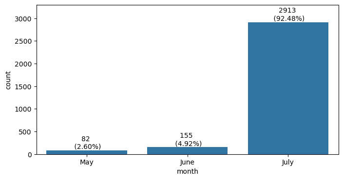

```python
plt.figure(figsize=(8, 4))
sns.countplot(x=data['month'])
plt.xticks(ticks=range(0, 3), labels=['May', 'June','July'])
plt.ylim(0, 3300)
bars_count_show()
```

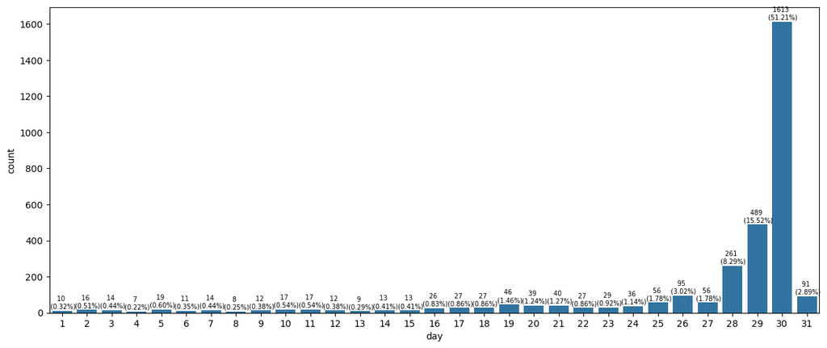

```python
plt.figure(figsize=(15, 6))
sns.countplot(x=data['day'])
bars_count_show(fontsize=7)
```

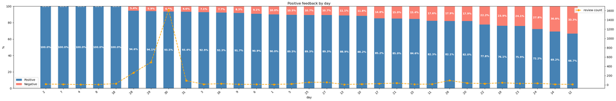

```
    day  mean  count  positive_pct  negative_pct
1     2  1.00     16        100.00          0.00
6     7  1.00     14        100.00          0.00
3     4  1.00      7        100.00          0.00
7     8  1.00      8        100.00          0.00
17   18  1.00     27        100.00          0.00
27   28  0.95    261         94.64          5.36
28   29  0.94    489         94.07          5.93
29   30  0.94   1613         93.55          6.45
30   31  0.93     91         93.41          6.59
2     3  0.93     14         92.86          7.14
15   16  0.92     26         92.31          7.69
8     9  0.92     12         91.67          8.33
5     6  0.91     11         90.91          9.09
0     1  0.90     10         90.00         10.00
```

[output cut: 17 more lines]

```python
positive_feedback(data, 'day',figsize=(30, 5))
```

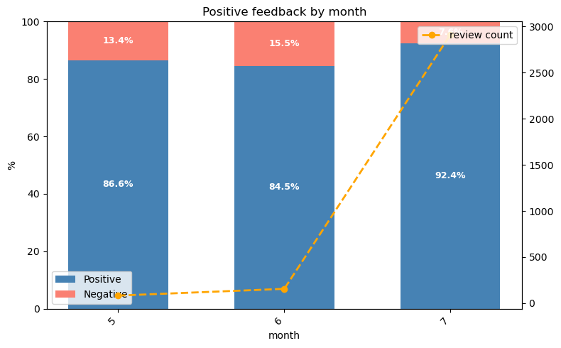

```
   month  mean  count  positive_pct  negative_pct
0      5  0.87     82         86.59         13.41
1      6  0.85    155         84.52         15.48
2      7  0.92   2913         92.38          7.62
```

```python
positive_feedback(data, 'month',figsize=(8, 5), sort_by=None)
```

### rating

```
rating
5    2286
4     455
1     161
3     152
2      96
Name: count, dtype: int64
```

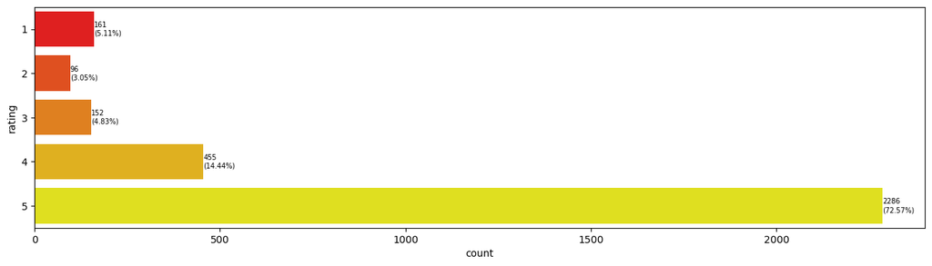

```python
plt.figure(figsize=(16, 4))
sns.countplot(y='rating', hue='rating', data=data, palette='autumn', legend=False)

bars_count_show(orientation=1, fontsize=7)

data.rating.value_counts()
```

График показывает преобладание хороших оценок, пользователи в большей степени остались довольны.

Так же на графике можно увидеть кол-во оценок и их процент.

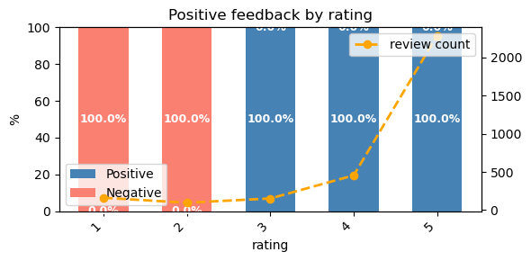

```
   rating  mean  count  positive_pct  negative_pct
0       1   0.0    161           0.0         100.0
1       2   0.0     96           0.0         100.0
2       3   1.0    152         100.0           0.0
3       4   1.0    455         100.0           0.0
4       5   1.0   2286         100.0           0.0
```

```python
positive_feedback(data, 'rating', figsize=(6, 3), sort_by=None)
```

Из графика видно что Amazon отнесла оценки:

1, 2 - к негативным отзывам

3, 4, 5 - к позитивным отзывам

Можем рассматривать переменную как бинарную. Учтем это при кодировании. Признак переведем в тип категориальных.

### variation

```python
data.variation.unique()
```

```
array(['Charcoal Fabric ', 'Walnut Finish ', 'Heather Gray Fabric ',
       'Sandstone Fabric ', 'Oak Finish ', 'Black', 'White',
       'Black  Spot', 'White  Spot', 'Black  Show', 'White  Show',
       'Black  Plus', 'White  Plus', 'Configuration: Fire TV Stick',
       'Black  Dot', 'White  Dot'], dtype=object)
```

```python
group = lambda x: (
    'Echo Dot' if 'dot' in x.lower() else
    'Echo Show' if 'show' in x.lower() else
    'Echo Spot' if 'spot' in x.lower() else
    'Echo Plus' if 'plus' in x.lower() else
    'Fire TV Stick' if 'stick' in x.lower() else
    'Echo'
)

data['device_type'] = data['variation'].map(group)
```

```python
data.device_type.unique()
```

```
array(['Echo', 'Echo Spot', 'Echo Show', 'Echo Plus', 'Fire TV Stick',
       'Echo Dot'], dtype=object)
```

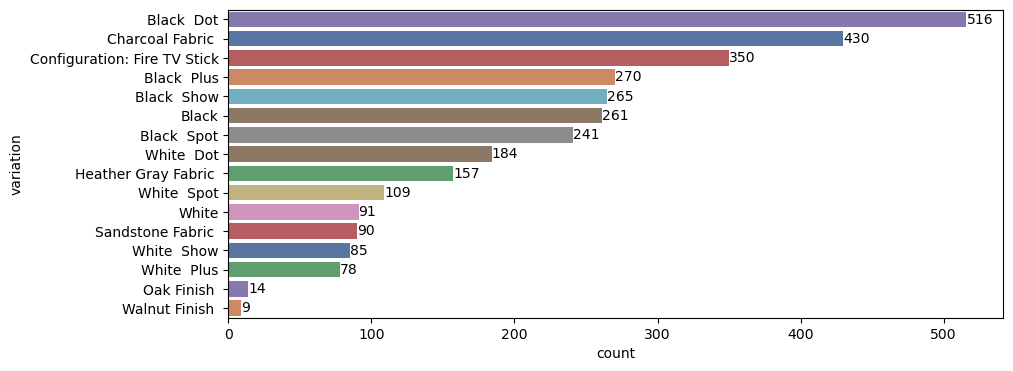

```python
plt.figure(figsize=(10, 4))
sns.countplot(hue='variation', y='variation', data=data, palette='deep', legend=False, order=data['variation'].value_counts().index)

bars_count_show(orientation=1, show_percent=False)
```

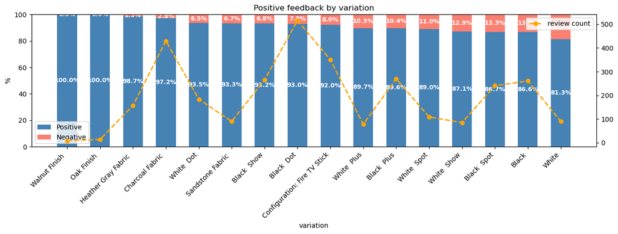

```
                       variation  mean  count  positive_pct  negative_pct
10                Walnut Finish   1.00      9        100.00          0.00
8                    Oak Finish   1.00     14        100.00          0.00
7           Heather Gray Fabric   0.99    157         98.73          1.27
5               Charcoal Fabric   0.97    430         97.21          2.79
12                    White  Dot  0.93    184         93.48          6.52
9              Sandstone Fabric   0.93     90         93.33          6.67
3                    Black  Show  0.93    265         93.21          6.79
1                     Black  Dot  0.93    516         93.02          6.98
6   Configuration: Fire TV Stick  0.92    350         92.00          8.00
13                   White  Plus  0.90     78         89.74         10.26
2                    Black  Plus  0.90    270         89.63         10.37
15                   White  Spot  0.89    109         88.99         11.01
14                   White  Show  0.87     85         87.06         12.94
4                    Black  Spot  0.87    241         86.72         13.28
0                          Black  0.87    261         86.59         13.41
11                         White  0.81     91         81.32         18.68
```

```python
positive_feedback(data, 'variation', figsize=(13,5))
```

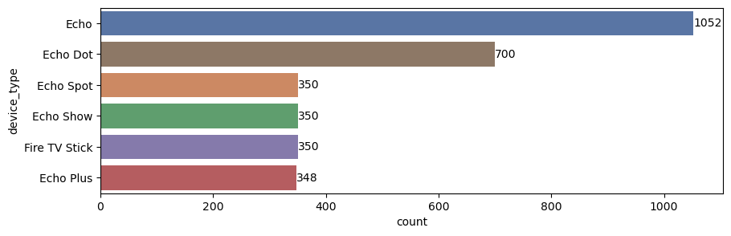

```python
plt.figure(figsize=(10, 3))
ax = sns.countplot(hue='device_type', y='device_type', data=data, palette='deep', legend=False, order=data['device_type'].value_counts().index)

bars_count_show(orientation=1, show_percent=False)
```

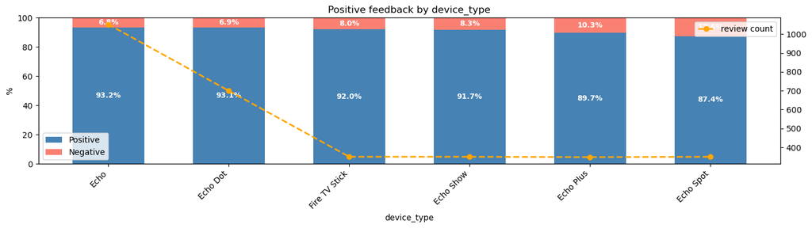

```
     device_type  mean  count  positive_pct  negative_pct
0           Echo  0.93   1052         93.16          6.84
1       Echo Dot  0.93    700         93.14          6.86
5  Fire TV Stick  0.92    350         92.00          8.00
3      Echo Show  0.92    350         91.71          8.29
2      Echo Plus  0.90    348         89.66         10.34
4      Echo Spot  0.87    350         87.43         12.57
```

```python
positive_feedback(data, 'device_type', figsize=(14, 4))
```

Наименее удачные модели устройств c негативными отзывами более 10% были:

- Echo Spot
- Echo Plus

## Предварительный итог.

### `verified_reviews` В задаче определения характера отзыва этот признак будет основой модели. Именно текст содержит реальное мнение покупателя — слова, тональность, эмоции.

### `rating` вероятно что переменная рейтинга будет причиной переобучения, так как по принципу оценок просто разделит данные на хорошо и плохо.

### `date` дата имеет низкую значимость в предсказании характера отзыва, так как взята выборка за маленький период времени, устройства одинаковые, одного поколения.

### `variation` вариация устройства может быть статистически не надежна и вносить шум, так как некторые версии устройства были куплены в незначительных кол-вах.

## verified_reviews

```python
# удалим строку с пропуском в отзывах
data = data.dropna().reset_index(drop=True)
```

```python
data.shape
```

```
(3149, 8)
```

```python
# признак длины отзыва
data['review_length'] = data['verified_reviews'].apply(lambda x: len(str(x)))
```

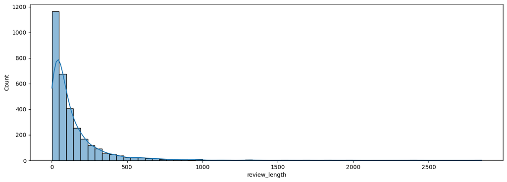

```python
plt.figure(figsize=(15, 5))
sns.histplot(data.review_length, bins=60, kde=True)
```

```python
# Разбиваем на бины
bins = [0, 50, 100, 200, 300, 500, 1000, 5000]
labels = ['0–50', '51–100', '101–200', '201–300', '301–500', '501–1000', '1000+']
data['length_bin'] = pd.cut(data['review_length'], bins=bins, labels=labels)
```

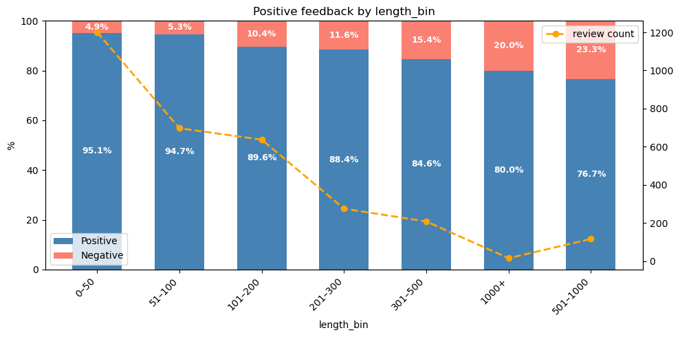

```
  length_bin  mean  count  positive_pct  negative_pct
0       0–50  0.95   1201         95.09          4.91
1     51–100  0.95    697         94.69          5.31
2    101–200  0.90    637         89.64         10.36
3    201–300  0.88    275         88.36         11.64
4    301–500  0.85    208         84.62         15.38
6      1000+  0.80     15         80.00         20.00
5   501–1000  0.77    116         76.72         23.28
```

```python
positive_feedback(data, 'length_bin', figsize=(10, 5))
```

```python
# посмотрим самый короткий отзыв и самый длинный
data.review_length.describe()
```

```
count    3149.000000
mean      132.090187
std       182.114569
min         1.000000
25%        30.000000
50%        74.000000
75%       165.000000
max      2851.000000
Name: review_length, dtype: float64
```

```python
# пустые комментарии
data[data.verified_reviews == ' ']
```

|  | rating | date | variation | verified_reviews | feedback | month | day | device_type | review_length | length_bin |
| --- | --- | --- | --- | --- | --- | --- | --- | --- | --- | --- |
| 85 | 5 | 2018-07-30 | Heather Gray Fabric |  | 1 | 7 | 30 | Echo | 1 | 0–50 |
| 183 | 3 | 2018-07-29 | Heather Gray Fabric |  | 1 | 7 | 29 | Echo | 1 | 0–50 |
| 219 | 5 | 2018-07-29 | Sandstone Fabric |  | 1 | 7 | 29 | Echo | 1 | 0–50 |
| 374 | 1 | 2018-07-26 | Black |  | 0 | 7 | 26 | Echo | 1 | 0–50 |
| 406 | 1 | 2018-07-16 | White |  | 0 | 7 | 16 | Echo | 1 | 0–50 |
| ... | ... | ... | ... | ... | ... | ... | ... | ... | ... | ... |
| 3113 | 3 | 2018-07-30 | Black Dot |  | 1 | 7 | 30 | Echo Dot | 1 | 0–50 |
| 3119 | 5 | 2018-07-30 | Black Dot |  | 1 | 7 | 30 | Echo Dot | 1 | 0–50 |
| 3122 | 4 | 2018-07-30 | Black Dot |  | 1 | 7 | 30 | Echo Dot | 1 | 0–50 |
| 3125 | 5 | 2018-07-30 | Black Dot |  | 1 | 7 | 30 | Echo Dot | 1 | 0–50 |
| 3140 | 3 | 2018-07-30 | Black Dot |  | 1 | 7 | 30 | Echo Dot | 1 | 0–50 |

79 rows × 10 columns

```python
empty_review_count = (data.verified_reviews == ' ').sum()
print(f'Процент пустых комментариев: {(empty_review_count / data.shape[0] * 100):.2f}%')
print(f'Количество пустых комментариев: {empty_review_count}')
```

```
Процент пустых комментариев: 2.51%
Количество пустых комментариев: 79
```

```python
data_no_empty = data[data.verified_reviews != ' ']
data_no_empty.shape
```

```
(3070, 10)
```

```python
# Самые короткие отзывы
data_no_empty[data_no_empty.review_length == 1]
```

|  | rating | date | variation | verified_reviews | feedback | month | day | device_type | review_length | length_bin |
| --- | --- | --- | --- | --- | --- | --- | --- | --- | --- | --- |
| 60 | 5 | 2018-07-30 | Heather Gray Fabric | 😍 | 1 | 7 | 30 | Echo | 1 | 0–50 |
| 754 | 5 | 2018-07-30 | Heather Gray Fabric | 😍 | 1 | 7 | 30 | Echo | 1 | 0–50 |

Короткие комментарии в виде смайликов не несут никакой ценной информации.

```python
# Самый длинный отзыв
data[data.review_length == 2851]['verified_reviews'].iloc[0]
```

```
"Incredible piece of technology.I have this right center of my living room on an island kitchen counter. The mic and speaker goes in every direction and the quality of the sound is quite good. I connected the Echo via Bluetooth to my Sony soundbar on my TV but find the Echo placement and 360 sound m…
```

```python
duplicates = data_no_empty.duplicated(subset=['verified_reviews', 'rating', 'date', 'variation'], keep='first')
print(f"Количество всех дубликатов: {duplicates.sum()}")
```

```
Количество всех дубликатов: 686
```

```python
# Дубликаты по отзывам и кол-во
duplicates_view = (
    data_no_empty[duplicates]
    .groupby('verified_reviews')
    .size()
    .reset_index(name='count')
    .sort_values('count', ascending=False)
)
duplicates_view
```

|  | verified_reviews | count |
| --- | --- | --- |
| 353 | Love it! | 8 |
| 347 | Love it | 6 |
| 220 | I love it | 3 |
| 120 | Great product | 3 |
| 111 | Great | 3 |
| ... | ... | ... |
| 657 | wonderful product and fast delivery! | 1 |
| 658 | works great | 1 |
| 659 | works great but speaker is not the good for mu... | 1 |
| 660 | works like any other one! | 1 |
| 5 | AMAZING. It has helped me become better organi... | 1 |

662 rows × 2 columns

```python
# Пример дубликата
data[data.verified_reviews == 'Love it!']
```

|  | rating | date | variation | verified_reviews | feedback | month | day | device_type | review_length | length_bin |
| --- | --- | --- | --- | --- | --- | --- | --- | --- | --- | --- |
| 98 | 4 | 2018-07-30 | Charcoal Fabric | Love it! | 1 | 7 | 30 | Echo | 8 | 0–50 |
| 101 | 5 | 2018-07-30 | Heather Gray Fabric | Love it! | 1 | 7 | 30 | Echo | 8 | 0–50 |
| 273 | 5 | 2018-07-29 | Heather Gray Fabric | Love it! | 1 | 7 | 29 | Echo | 8 | 0–50 |
| 461 | 5 | 2018-07-02 | Black | Love it! | 1 | 7 | 2 | Echo | 8 | 0–50 |
| 792 | 4 | 2018-07-30 | Charcoal Fabric | Love it! | 1 | 7 | 30 | Echo | 8 | 0–50 |
| 795 | 5 | 2018-07-30 | Heather Gray Fabric | Love it! | 1 | 7 | 30 | Echo | 8 | 0–50 |
| 967 | 5 | 2018-07-29 | Heather Gray Fabric | Love it! | 1 | 7 | 29 | Echo | 8 | 0–50 |
| 1148 | 5 | 2018-07-29 | Black Spot | Love it! | 1 | 7 | 29 | Echo Spot | 8 | 0–50 |
| 1258 | 5 | 2018-07-25 | Black Spot | Love it! | 1 | 7 | 25 | Echo Spot | 8 | 0–50 |
| 1323 | 5 | 2018-07-21 | Black Spot | Love it! | 1 | 7 | 21 | Echo Spot | 8 | 0–50 |
| 1411 | 5 | 2018-07-30 | Black Show | Love it! | 1 | 7 | 30 | Echo Show | 8 | 0–50 |
| 1418 | 5 | 2018-07-30 | Black Show | Love it! | 1 | 7 | 30 | Echo Show | 8 | 0–50 |
| 1515 | 5 | 2018-07-30 | Black Show | Love it! | 1 | 7 | 30 | Echo Show | 8 | 0–50 |
| 1524 | 5 | 2018-07-30 | Black Show | Love it! | 1 | 7 | 30 | Echo Show | 8 | 0–50 |
| 1602 | 5 | 2018-07-29 | Black Show | Love it! | 1 | 7 | 29 | Echo Show | 8 | 0–50 |
| 1701 | 5 | 2018-07-28 | White Show | Love it! | 1 | 7 | 28 | Echo Show | 8 | 0–50 |
| 1890 | 5 | 2018-07-27 | White Plus | Love it! | 1 | 7 | 27 | Echo Plus | 8 | 0–50 |
| 2126 | 4 | 2018-07-31 | Configuration: Fire TV Stick | Love it! | 1 | 7 | 31 | Fire TV Stick | 8 | 0–50 |
| 2238 | 5 | 2018-07-30 | Configuration: Fire TV Stick | Love it! | 1 | 7 | 30 | Fire TV Stick | 8 | 0–50 |
| 2380 | 5 | 2018-07-30 | Configuration: Fire TV Stick | Love it! | 1 | 7 | 30 | Fire TV Stick | 8 | 0–50 |
| 2700 | 5 | 2018-07-30 | Black Dot | Love it! | 1 | 7 | 30 | Echo Dot | 8 | 0–50 |
| 3051 | 5 | 2018-07-30 | Black Dot | Love it! | 1 | 7 | 30 | Echo Dot | 8 | 0–50 |

```python
# Удалим дубликаты и смайлы
data_clear = data_no_empty[data_no_empty.review_length != 1].drop_duplicates(subset=['verified_reviews', 'rating', 'date', 'variation'], keep='first').reset_index(drop=True)
print(f"Осталось строк после удаления: {data_clear.shape[0]}")
```

```
Осталось строк после удаления: 2383
```

```python
vectorizer = CountVectorizer(stop_words = 'english', max_features=2500)
alexa_countvectorizer = vectorizer.fit_transform(data_clear['verified_reviews'])
```

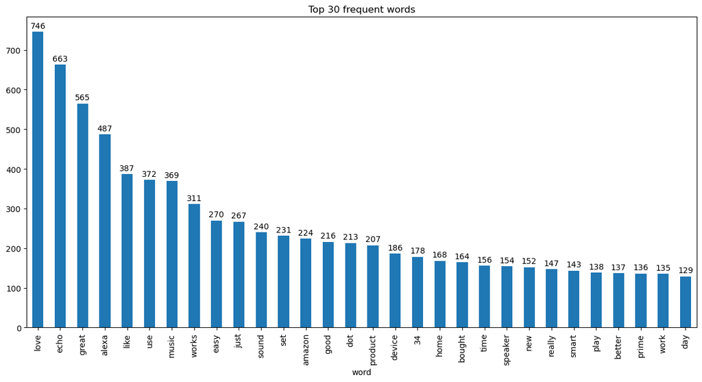

```python
# Топ 30 слов, по частоте использования
sum_words = alexa_countvectorizer.sum(axis=0)
words_freq = [(word, sum_words[0, idx]) for word, idx in vectorizer.vocabulary_.items()]
words_freq = sorted(words_freq, key = lambda x: x[1], reverse = True)

frequency = pd.DataFrame(words_freq, columns=['word', 'freq'])

frequency.head(30).plot(kind='bar', x='word', y='freq', figsize=(15, 7), legend=False)

bars_count_show(show_percent=False)

plt.title("Top 30 frequent words")
plt.show()
```

# 📊 Итоги:

## Анализ переменных

### `feedback` — целевая переменная

> **Ключевая проблема: дисбаланс классов**

| Класс | Кол-во | % |
| --- | --- | --- |
| 1 — позитивный | ~2 893 | 91.84% |
| 0 — негативный | ~257 | 8.16% |

Модель, предсказывающая **всегда класс 1**, даст Accuracy = 91.84% — но будет бесполезна.  
→ Фокус на метриках для класса 0: **Precision, Recall, F1, ROC-AUC, PR-AUC**

### `verified_reviews` — главный признак

[output not shown]

### `rating`

— исключить (target leakage)

| Rating | Feedback |
| --- | --- |
| 1, 2 | 0 — негатив |
| 3, 4, 5 | 1 — позитив |

Рейтинг **напрямую определяет** целевую переменную.  
Модель просто выучит это правило и не научится анализировать текст.  
→ **Исключить из признаков.**

### `variation`

— исключить (шум)

- 16 уникальных значений → высокая кардинальность
- Walnut Finish, Oak Finish → 100% позитивных, но куплены единицами — **статистически ненадёжно**
- Наибольший % негативных отзывов:

| Устройство | % негативных |
| --- | --- |
| Echo Spot | > 10% |
| Echo Plus | > 10% |

→ Заменить на `device_type` (6 групп) — или исключить совсем

### `date`

— исключить (нет сигнала)

- Период всего 3 месяца одного года
- Устройства одного поколения
- Сезонных паттернов не обнаружено
- → **Исключить из признаков**

### `device_type` - дополнительная переменная.

— опционально

Агрегированная версия `variation`:

[output not shown]

Меньше шума, чем `variation`. Слабый, но возможный сигнал.

## Очистка данных

- Удаление пропусков данных.
- Удаление пустых комментариев.
- Удаление дубликатов (совпадения по комбинации признаков)

## Инженерия признаков

| Признак | Тип | Трансформация | Включить |
| --- | --- | --- | --- |
| `verified_reviews` | текст | TF-IDF внутри Pipeline | ✅ |
| `review_length` | числовой | StandardScaler | ✅ |
| `device_type` | категория | OneHotEncoder | ✅ опционально |
| `rating` | числовой | — | ❌ target leakage |
| `variation` | категория | — | ❌ шум |
| `date` | дата | — | ❌ нет сигнала |
| `month` / `day` | дата | — | ❌ производные от date |

## Разбивка данных

- Используем стратифицированное разбиение train/test, для сохранения пропорции классов.
- Диапозон теста уменьшаем со стандартных 20-30% до 15-20%, чтобы больше примеров редкого класса осталось в тренировке.

## Метрики оценки модели

| Метрика | Формула | Зачем |
| --- | --- | --- |
| **Precision** | TP / (TP + FP) | Точность обнаружения негатива |
| **Recall** | TP / (TP + FN) | Покрытие реальных негативных |
| **F1-score** | 2·P·R / (P+R) | Баланс Precision и Recall |
| **ROC-AUC** | площадь под ROC | Общая разделимость классов |
| **PR-AUC** | площадь под PR | Эффективность для класса 0 |

> Accuracy **бесполезна** при дисбалансе 92/8.

## Моделирование

| 1. Baseline | LogisticRegression (TF-IDF only) |
| --- | --- |
| 2. Linear | LogisticRegression, LinearSVC |
| 3. Tree-based | RandomForest, GradientBoosting, XGBoost |
| 4. Other | NaiveBayes, KNN |
| 5. Ensemble | SuperLearner |

- При настройке будем использовать параметры балансировки (`class_weight, sample_weight, scale_pos_weight, fit_prior` в зависимости от модели)

### Стратегия моделирования - настройка параметров с акцентом на улучшение выбранных метрик.

## Чеклист перед моделированием

- Удалены NaN
- Удалены пустые отзывы
- Удалены смайлы
- Удалены дубликаты
- `rating` исключён из признаков
- `review_length` добавлен как признак
- `device_type` создан из `variation`
- Данные разбиты с `stratify=y`
- TF-IDF обучается только на `X_train` (внутри Pipeline)
- Метрики выбраны с фокусом на класс 0